# Non-independence: Introduction

## IID is often violated

- Events are independent if the occurence of one does not influence the occurence of the other
- Assumption of most statistical tests
- In biological situations, independence assumption is often violated

[figure not shown]

## When is independence assumption violated?

- When there is a hierarchical structure to the data
  - e.g., several samples at each site
- Shared ancestry
  - Phylogenetic relatedness (between populations/species)
  - Genetic relatedness (between individuals within populations/species)
- Spatial relationships
- Sampling over time
- …

## Why is non-independence a problem?

Does higher altitude drive the evolution of higher levels of hemoglobin?

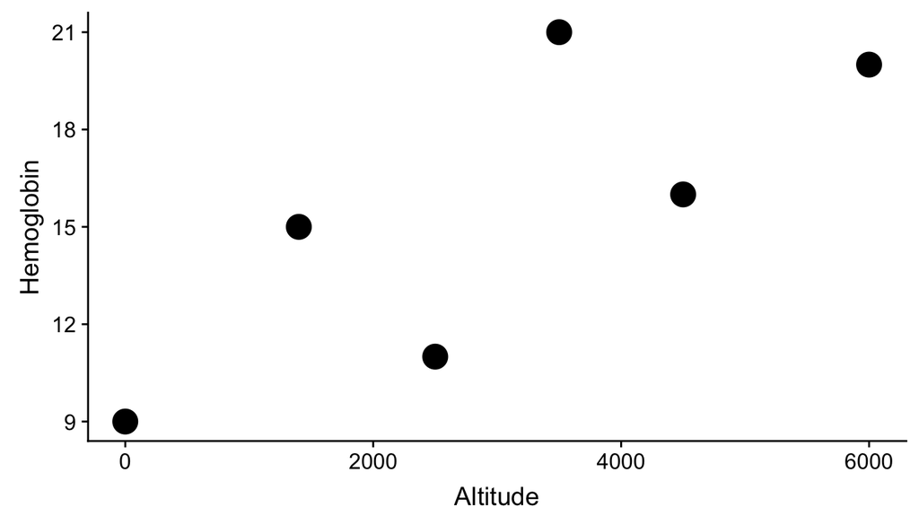

## Why is non-independence a problem?

Does higher altitude drive the evolution of higher levels of hemoglobin?

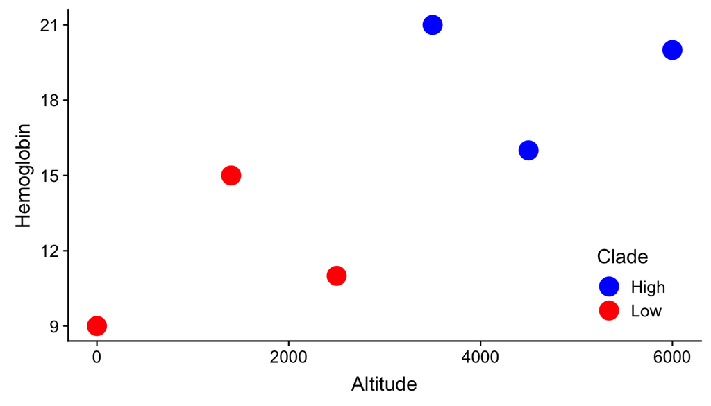

## Why is non-independence a problem?

**Pseudoreplication**: artificially inflated sample size lead to unfounded confidence

[figure not shown]

## Conventional statistics assume

[figure not shown]

## Best case for this example

[figure not shown]

## Genotype-Phenotype Relationships

Is a given genotype associated with a phenotype of interest?

- Consider two populations with ancestry differences
- Not accounting for ancestry differences can lead to spurious associations
- Population structure & relatedness are issues for all genetic association studies

## Genotype-Phenotype Relationships

Is a given genotype associated with a phenotype of interest?

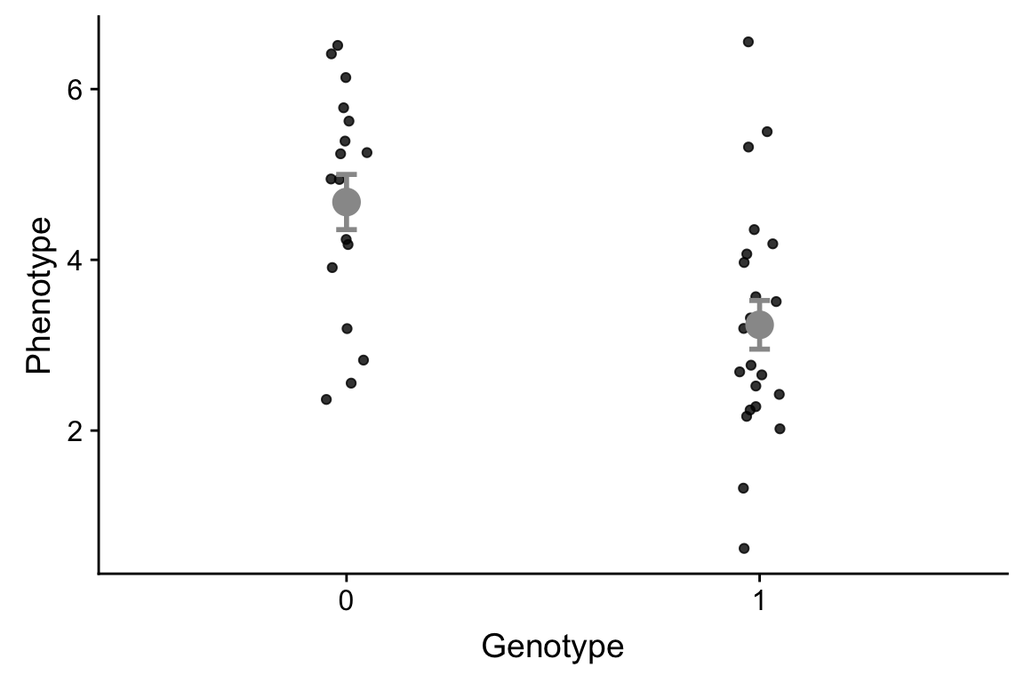

## Genotype-Phenotype Relationships

An effect of both 1) different allele frequency in two pops, and 2) different average trait value in two pops

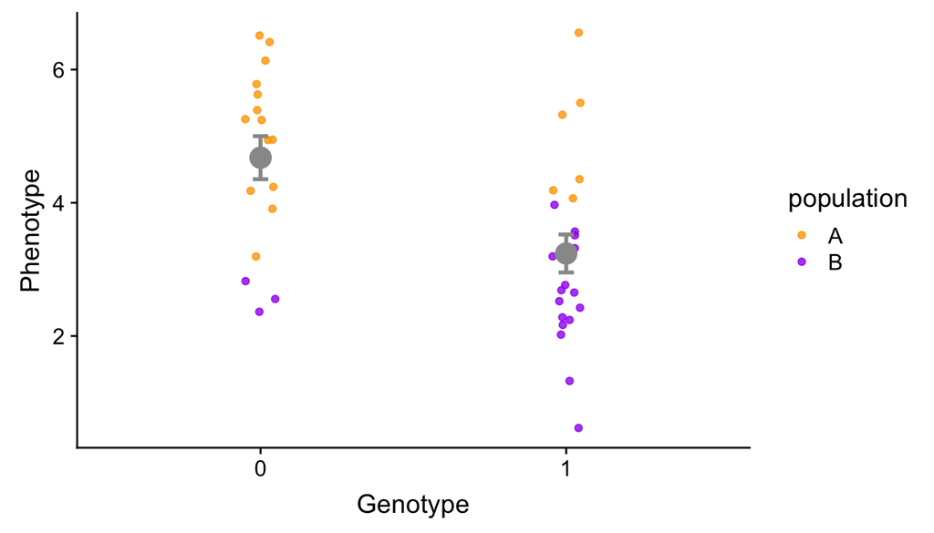

## No Quiz

Lecture 11-2